# Introduction

Autoregressive-Moving Average (ARMA) time series models are commonly used for fitting time-series and Generalized Autoregressive Conditional Heterokedasticity (GARCH) time series models are commonly used to account for heteroskedasticity (non-constant volatility) by assuming volatility is a deterministic function of past values. LSTM models are a recurrent neural network capable of capturing long-term dependence. It will be shown that LSTM models can fit simulated ARMA(1,1)-GARCH(1,1) processes (although this is overkill as models of lag 1 do not exhibit long-term dependence).

# Simulating an ARMA(1,1)-GARCH(1,1) process

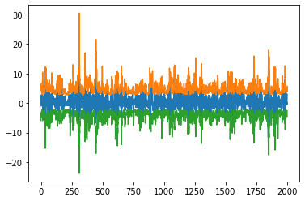

```python
import matplotlib.pyplot as plt
import numpy as np

def simARMA11GARCH11(length,mu,a,b,omega,alpha,beta):
    """
    This function returns an ARMA(1,1)-GARCH(1,1) process
    with parameters mu, a, b, omega, alpha, and beta of
    length 'length' with Gaussian residuals.
    xt is the value of the process,
    ht is the conditional varianc of xt at time t-1
    xhatt is the expected value of xt at time t-1
    """
    zt = np.random.normal(0,1,length)
    xt = []
    xhatt = []
    ht = [omega/(1-alpha-beta)]
    for ii in range(len((zt))):
        if ii == 0:
            xt.append(mu+np.sqrt(ht[ii])*zt[ii])
            xhatt.append(mu)
        else:
            ht.append(omega+alpha*(np.sqrt(ht[ii-1])*zt[ii-1])**2+beta*ht[ii-1])
            xt.append(mu+b*xt[ii-1]+a*zt[ii-1]+np.sqrt(ht[ii])*zt[ii])
            xhatt.append(mu+b*xt[ii-1]+a*zt[ii-1])
    return([xt,ht, xhatt])

xt,ht, xhatt = simARMA11GARCH11(2000,0.3,0.5,0.1,1,0.45,0.45)

#plots the actual process xt
plt.plot(xt)
#plots the 95% confidence interval of xt at time t-1
plt.plot(xhatt+1.96*np.sqrt(ht))
plt.plot(xhatt-1.96*np.sqrt(ht))
plt.show()
```

# Defining the pytorch LSTM model

The only feature here is $x_{t-1}$. The outputs are $x_t$ and the conditional variance $h_t$, made non-negative using an exponential activation function. The neural network features a linear layer with relu activations, a dropout layer to prevent overfitting, a linear layer into the LSTM, and then a linear layer, relu activation, dropout to prevent overfitting, and then a linear layer for the output.

```python
import torch
from torch import nn
import torch.nn.functional as F
import numpy as np

device = torch.device("cuda" if torch.cuda.is_available() else "cpu")

class LSTM1(torch.nn.Module):
    def __init__(self):
        super().__init__()
        self.l0 = nn.Linear(1,32)
        self.l01 = nn.Linear(32,2)
        self.l1 = nn.LSTM(2,2,1)
        self.l2 = nn.Linear(2,32)
        self.dropout = nn.Dropout(0.2)
        self.l3 = nn.Linear(32,2)

    def forward(self, X):
        X0 = []
        for ii in range(len(X)):
            Xi=F.relu(self.l0(X[ii]))
            Xi=self.dropout(Xi)
            X0.append(self.l01(Xi))

        X0 = torch.reshape(torch.cat(X0,0),(len(X0),2))
        X2,hh = self.l1(X0)

        X4 = []
        for ii in range(len(X2)):
            X3=F.relu(self.l2(X2[ii]))
            X3=self.dropout(X3)
            X4.append(self.l3(X3))

        X4 = torch.stack(X4)
        xhat = X4[:,0]
        vhat = torch.exp(X4[:,1])
        return xhat, vhat


model = LSTM1()
```

# The data set

The data set is split into a training and test set, and normalized according to the training sets mean and variance.

```python
train = xt[:int(np.floor(len(xt)*0.8))]
test = xt[int(1+np.floor(len(xt)*0.8)):]

mu = np.mean(train)
sd = np.std(train)

train = (train-mu)/sd
test = (test-mu)/sd

#input is all but the last data point
trainx = torch.reshape(torch.tensor(train[:-1]).float(),(-1,1))
testx = torch.reshape(torch.tensor(test[:-1]).float(),(-1,1))
#output is all but the first data point
trainy = torch.reshape(torch.tensor(train[1:]).float(),(-1,1))
testy =  torch.reshape(torch.tensor(test[1:]).float(),(-1,1))
```

# Training

The neural network is trained and test and training losses are displayed (computed every 100 iterations) (remove epochs). The loss function used is the Gaussian negative log-likelihood. The optimizer is ADAM with weight decay to prevent overfitting. To accelerate training, the model is trained on a small random subset of size $k$ of the training data at each iteration. Losses are computed every 100 iterations for the training and test data.

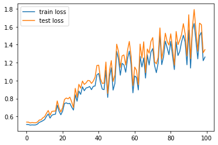

```python
learning_rate = 0.001
loss_fn = nn.GaussianNLLLoss(eps = 1e-12,reduction='mean')
optimizer = torch.optim.Adam(model.parameters(), lr=learning_rate,weight_decay=1e-5)

iterations = 10000
k=5
train_loss = []
test_loss = []
for ii in range(iterations):
    start = np.random.default_rng().integers(0,len(trainx)-k)
    x1 = trainx[start:(start+k)]
    y1 = trainy[start:(start+k)]
    xhat,vhat=model(x1)
    loss = loss_fn(xhat, y1,vhat)
    optimizer.zero_grad()
    loss.backward()
    optimizer.step()
    if ii%100 == 0:
        #print(ii)
        with torch.no_grad():
            xhat,vhat=model(trainx)
            train_loss.append(loss_fn(xhat, trainy,vhat).detach().numpy())
            xhat,vhat=model(testx)
            test_loss.append(loss_fn(xhat, testy,vhat).detach().numpy())

plt.plot(train_loss,label = "train loss")
plt.plot(test_loss,label = "test loss")
plt.legend()
plt.show()
```

# Results

The data and predicted 95% confidence interval is plotted as well as the data and the predictions.

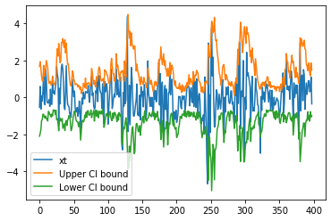

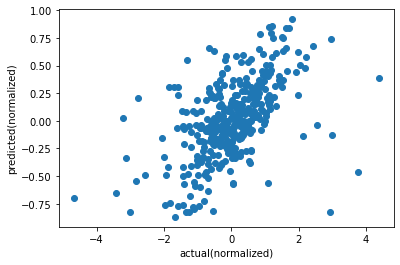

```python
xhat,vhat=model(testx)

plt.plot(testx.detach().numpy(),label='xt')
plt.plot(xhat.detach().numpy()+1.96*np.sqrt(vhat.detach().numpy()),label='Upper CI bound')
plt.plot(xhat.detach().numpy()-1.96*np.sqrt(vhat.detach().numpy()),label='Lower CI bound')
plt.legend()
plt.show()

plt.scatter(testx.detach().numpy(),xhat.detach().numpy())
plt.xlabel('actual(normalized)')
plt.ylabel('predicted(normalized)')
plt.show()
```

# Conclusion

The LSTM output is clearly correlated with the actual time series. As well, we can see reasonable heteroskedasticity in the confidence intervals. In other words, the LSTM neural network is able to model ARMA(1,1)-GARCH(1,1) processes. Expanding on this work the neural network could be applied to financial time series or used in reinforcement learning for portfolio optimization as the architecture can capture the mean and variance necessary for mean-variance optimal portfolios.